# Encryptr: Easily Encrypt and Decrypt Sensitive Data with R

2019-Sep-13

## Why we are waking up to the value of our own data

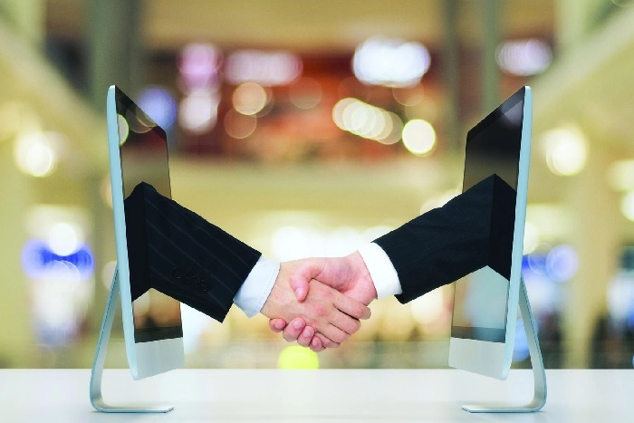

Scotsman, Aug-30, 2019

## Data Governance

- Data is precious and sensitive
- Confidential data (when possible) should be anonymised or pseudonomysed
- Patients expect us to safeguard their data
- Solutions include removing unnecessary data and securing necessary data

## Research and Data

- Data governance approvals are key components of research approvals
- GDPR (Europe) and HIPAA etc. (USA)
- Data breaches are financially and reputationally costly
- Not all data can be removed from records

## Encryptr

- Easy pseudonymisation by encryption
- RSA encryption with private / public key pair
- Encryption of vectors, variables and files
- Secure storage of confidential data (and allocation concealment / blinding)

## Encryptr on CRAN / Github

```r
install.packages("encryptr") # CRAN
remotes::install_github("SurgicalInformatics/encryptr")
```

https://github.com/surgicalinformatics

```r
library(encryptr)
library(dplyr) # Used in presentation examples

# Encryptr comes with an example data set of GPs (Family Physicians)
gp
```

```
## # A tibble: 1,212 x 12
##   organisation_code name                    address1       address2   address3 city    county  postcode opendate   closedate  telephone  practice_type
##   <chr>             <chr>                   <chr>          <chr>      <chr>    <chr>   <chr>   <chr>    <date>     <date>     <chr>              <dbl>
## 1 S10002            MUIRHEAD MEDICAL CENTRE LIFF ROAD      MUIRHEAD   <NA>     DUNDEE  ANGUS   DD2 5NH  1995-05-01 NA         01382 580…             4
## 2 S10017            THE BLUE PRACTICE       CRIEFF MEDICA… KING STRE… <NA>     CRIEFF  PERTHS… PH7 3SA  1996-04-06 NA         01764 652…             4
## 3 S10036            ABERFELDY AND KINLOCH … TAYBRIDGE ROAD <NA>       <NA>     ABERFE… PERTHS… PH15 2BL 2008-04-01 NA         01887 820…             4
## 4 S10060            ABERFELDY HEALTH CENTRE TAYBRIDGE ROAD <NA>       <NA>     ABERFE… PERTHS… PH15 2BH 1975-04-01 2008-03-31 01887 820…             4
## 5 S10106            GROVE HEALTH CENTRE     129 DUNDEE RO… BROUGHTY … <NA>     DUNDEE  ANGUS   DD5 1DU  1996-07-08 NA         01382 778…             4
## 6 S10125            ALYTH HEALTH CENTRE     NEW ALYTH ROAD ALYTH      <NA>     BLAIRG… PERTHS… PH11 8EQ 1979-10-01 NA         01828 632…             4
## # … with 1,206 more rows
```

## Public and Private Keys

```r
genkeys()
```

```
## Private key written with name 'id_rsa'
## Public key written with name 'id_rsa.pub'
```

Default values are “id_rsa” and “id_rsa.pub”

## No Raw Text Password

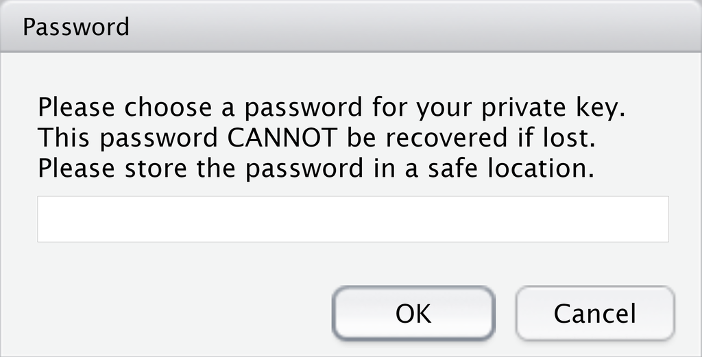

```r
gp_encrypt = gp %>%
  encrypt(name)
gp_encrypt %>%
  select(organisation_code, name, address1)
```

```
## # A tibble: 1,212 x 3
##   organisation_code name                                                                                                             address1
##   <chr>             <chr>                                                                                                            <chr>
## 1 S10002            71d071f79fdd3e794c623868eb7aa9ced57751e920ab5c8adcfe4c31164306a744c8379c9abc5932c7fd889d95975698848daafbe9f1ba0… LIFF ROAD
## 2 S10017            575d22a1a0a8899ec862daa99d2c49d1ff679337e9f70d0a89213681a948894373ec4b7ce0740f8f85076605040f5fbcddf97f7204f69e5… CRIEFF MEDICAL C…
## 3 S10036            3501963764bdcd8179ee32d3d5c79a18a0d16ee6bb6ef49dfa36296a41e2ff6e946db531321f118fd26bfacb6a85c3b15403da62da1599c… TAYBRIDGE ROAD
## 4 S10060            9e0e09a67e8e5e0c82184ca0b8e22524e7c96493c4c399651a5d2f65c599ad18e8c4aff33a1c7ce4869d47ede1483da622c4d5fae92a57e… TAYBRIDGE ROAD
## 5 S10106            13695fafc81089dd1f7aae30626ac2d1b0986754d3bdb927d14fb849cd84547304851d98f09192af31a5cd4776ac13a9a198c82c4ba3ac8… 129 DUNDEE ROAD
## 6 S10125            9aafa39309e277a37273cdbfc96f337bc3858a007e30bb1bbcb346fbbf66a210ffa5f2065ca1ebaca20de782ed3057406d9f61aa0994bc3… NEW ALYTH ROAD
## # … with 1,206 more rows
```

```r
gp_encrypt %>%
  slice(1:2) %>%
  decrypt(name) %>%
  select(organisation_code, name, address1)
```

```
## # A tibble: 2 x 3
##   organisation_code name                    address1
##   <chr>             <chr>                   <chr>
## 1 S10002            MUIRHEAD MEDICAL CENTRE LIFF ROAD
## 2 S10017            THE BLUE PRACTICE       CRIEFF MEDICAL CENTRE
```

## Encryptr Customisation

- Use look-up table - create object with encrypted output and ID variable on which to match
- Write a look-up file
- Customise file names, key names, encrypt several variables
- Use a publicly-available public key

## Encryptr Customisation Examples

```r
# Creating a lookup table with specified name and filename
gp %>%
  encrypt(name, postcode,
          lookup = TRUE, write_lookup = TRUE,
          lookup_name = "new_lookup_name")


# Using a public key hosted at URL
gp %>%
  encrypt(name, public_key_path = "https://<some_url>/id_rsa.pub")
```

## Encryptr File Encryption

```r
gp_encrypt %>% write_csv("gp_enc.csv")

encrypt_file("gp.csv")



# Encrypted file will have suffix: `.encryptr.bin`
decrypt_file("gp.csv.encryptr.bin", file_name = "gp2.csv")
```

## Encryptr Ciphertexts Not Matchable

- Each repeat of encryption generates a unique number
- Prevents malicious, opportunistic use of public key
- Alternative symmetric encryption outputs can be matched (and not always reversed)
- Alternative methods need a “salt”

```r
encrypt_vec(c("a name", "a name", "a name"))
```

```
## [1] "1369a4a7ff5337cbc2af1e3eec03e9caafb023f0343182d6a10b3088dcc4…"
## [2] "8f808495bcc38816876fba76a3935ef893eb28a747396dc807a2fbfcb83a…"
## [3] "4c803f317f568a21aba6245af9ce1665761547d1169b107af7713616d1f4…"
```

## Technical Aspects of Encryptr

- Wrapper around OpenSSL (and purrr)
- RSA asymmetric encryption for vectors (each component in vector < 256 bytes)
- File encryption uses AES technique with symmetric session key which is in turn encrypted by RSA public key

## What Encryptr Is Useful For

- Storing confidential data in trials, cohorts, service evaluation, etc.
- Retrieving individual data if needed
- Blinding in RCTs
- Data governance considerations